# Predicting stroke risk from common health indicators: a binary logistic regression analysis

Authors

Shree Krishna M.S Basnet

Renan

Supervisor: Dr. Cohen

Published

December 2, 2025

# 1 Introduction

Stroke is a global health crisis, causing widespread mortality and disability<sup>[**WHO2025?**]</sup>. Because strokes occur suddenly and often lead to long-term neurological damage, early detection in high-risk individuals is critical for prevention and prompt intervention. By using data-driven risk prediction models, clinicians and public health experts can better identify high-risk populations, allowing for targeted clinical management and lifestyle counseling.

Logistic Regression (LR) is one of the most widely used methods for modeling binary outcomes, such as the presence or absence of a disease<sup>[**sperandei2014understanding?**]</sup>. It extends linear regression to categorical outcomes, providing interpretable coefficients that explain how specific factors influence the probability of an event. LR has been applied across diverse fields, including child health<sup>[**asmare2024determinants?**]</sup>, road safety<sup>[**rahman2021identification?**,**chen2024binary?**,**chen2020modeling?**]</sup>, healthcare resource management<sup>[**hutchinson2023predictors?**]</sup>, and fraud detection<sup>[**samara2024using?**]</sup>. These varied applications demonstrate LR’s flexibility and suitability for real-world decision-making.

In this project, we analyze a publicly available stroke dataset containing key demographic, behavioral, and clinical predictors—such as age, gender, hypertension, heart disease, marital status, work type, residence, smoking status, Body Mass Index (BMI), and average glucose level. These variables are well-documented in cardiovascular literature as significant risk determinants. We cleaned and recoded this data into appropriate numeric formats to develop a series of supervised learning models.

We establish Logistic Regression as our primary, interpretable baseline model and compare its performance against more complex machine learning techniques, including Decision Tree, Random Forest, Gradient Boosted Machine, $k$-Nearest Neighbours, and Support Vector Machine (radial).

# 2 Methodology

This section outlines our data, how we prepared it, and the modeling framework we used to compare different classifiers.

We started with a dataset of 5,110 observations and 11 predictors commonly linked to stroke risk. We filtered out missing data and inconsistent entries—such as “Unknown,” “N/A,” or rare labels like “children”—which left us with a final group of 3,357 individuals. This clean dataset is stored in the object **`strokeclean`**.

Because our goal is to predict a binary outcome (Yes/No), Logistic Regression is our primary approach for determining if a patient has had a stroke ($Y=1$) or not ($Y=0$)<sup>[**hosmer2013applied?**,**james2021isl?**]</sup>.

**Variables**

The key predictors used in our analysis are listed below:

| Variable | Type | Description |
| --- | --- | --- |
| **age** | Numeric | Age of the individual (years) |
| **gender** | Categorical | Biological sex (Male/Female) |
| **hypertension** | Binary (0/1) | Prior hypertension diagnosis |
| **heart_disease** | Binary (0/1) | Presence of heart disease |
| **ever_married** | Binary | Marital status |
| **work_type** | Categorical | Employment category |
| **Residence_type** | Binary | Urban vs. Rural |
| **smoking_status** | Categorical | Never / Former / Smokes |
| **bmi** | Numeric | Body Mass Index |
| **avg_glucose_level** | Numeric | Average glucose level |
| **stroke** | Binary | Outcome (0=No, 1=Yes) |

**Addressing Class Imbalance with Resampling (SMOTE and ROSE)**

Our dataset is highly unbalanced:

- **Yes (Stroke):** ~5%
- **No (No Stroke):** ~95%

To address the severe deficiency in stroke detection (Sensitivity $\approx 2\%$) caused by class imbalance ($\approx 5\%$ stroke cases), we implemented two robust resampling techniques: SMOTE (Synthetic Minority Over-sampling Technique) and ROSE (Random Over-Sampling Examples). These methods were applied during the cross-validation phase of training the best original models (LR, RF, and GBM) to create balanced training data. The primary goal was to improve the model’s ability to learn and classify the rare stroke event, thereby dramatically increasing Sensitivity.

**Dataset Preparation**

To ensure our model is valid and to prevent “data leakage” (where the model accidentally sees data it shouldn’t), we applied several preprocessing steps<sup>[**wang2014?**]</sup>:

- **Removed Identifiers:** We dropped columns like Patient ID since they don’t predict medical risk.
- **Cleaned Labels:** We removed rows with vague labels (e.g., “Unknown”) and standardized rare categories.
- **Numeric Conversion:** We converted age, BMI, and glucose levels into standard numeric formats and turned categorical variables (like gender) into dummy variables.
- **Consistency Checks:** We verified that all values fell within realistic ranges.

**Model Validation**

Finally, we split the data into training and testing sets. For the machine-learning comparison, we used **stratified sampling** (via `caret::createDataPartition`). This ensures that the ratio of stroke to non-stroke patients remains consistent in both the training and testing data, preventing the model from learning from a skewed sample<sup>[**chen2020modeling?**]</sup>.

**Logistic regression model**

Let $Y_i$ denote the stroke status for patient $i$, where

- $Y_i = 1$ if patient $i$ experienced a stroke
- $Y_i = 0$ otherwise.

Let the predictor vector for patient $i$ be

$$\mathbf{x}_i = (x_{i1}, x_{i2}, \ldots, x_{ip})^\top,$$

where the $p$ predictors such as age, hypertension, heart disease, average glucose level, BMI, and smoking status.

The logistic regression model specifies the conditional probability of stroke as

$$P(Y_i = 1 \mid \mathbf{x}_i)
= \pi(\mathbf{x}_i)
= \frac{\exp\big(\beta_0 + \beta_1 x_{i1} + \cdots + \beta_p x_{ip}\big)}
{1 + \exp\big(\beta_0 + \beta_1 x_{i1} + \cdots + \beta_p x_{ip}\big)}.$$

Equivalently, the logit (log-odds) of stroke is modeled as a linear combination of the predictors:

$$\log\left(\frac{\pi(\mathbf{x}_i)}{1 - \pi(\mathbf{x}_i)}\right)
= \beta_0 + \beta_1 x_{i1} + \cdots + \beta_p x_{ip}.$$

Here, $\beta_0$ is the intercept, $\beta_j$ is the change in log-odds of stroke for a one-unit increase in predictor $x_j$, holding other variables constant.

Exponentiating $\beta_j$ gives the odds ratio (OR):
$$\text{OR}_j = e^{\beta_j},$$

which represents the multiplicative change in the odds of stroke for a one-unit increase in $x_j$.

**Model Estimation**

Let $\boldsymbol{\beta} = (\beta_0, \beta_1, \ldots, \beta_p)^\top$ denote the vector of regression coefficients. For independent observations, the likelihood of the data is
$$L(\boldsymbol{\beta})
= \prod_{i=1}^{n}
\pi(\mathbf{x}_i)^{\,y_i}
\left[1 - \pi(\mathbf{x}_i)\right]^{\,1-y_i},$$

where $\pi(\mathbf{x}_i) = P(Y_i = 1 \mid \mathbf{x}_i)$.

The **log-likelihood** is

$$\ell(\boldsymbol{\beta})
= \sum_{i=1}^{n}
\left[
y_i \log\big(\pi(\mathbf{x}_i)\big)
+
(1 - y_i)\log\big(1 - \pi(\mathbf{x}_i)\big)
\right].$$

The maximum likelihood estimate $\hat{\boldsymbol{\beta}}$ is the value of $\boldsymbol{\beta}$ that maximizes $\ell(\boldsymbol{\beta})$. In R, this optimization is carried out automatically using `glm(..., family = binomial)`

**Machine Learning Models and Evaluation**

To see if advanced technology could outperform standard methods, we built six different supervised learning models using the `caret` framework. We wanted to determine if sophisticated algorithms could improve our ability to classify stroke risk compared to the baseline.

The six models were:

- **Logistic Regression (LR)** – Our baseline.
- **Decision Tree (rpart)** – A simple rule-based model.
- **Random Forest (RF)** – An ensemble of many decision trees.
- **Gradient Boosted Machine (GBM)** – A powerful, iterative learning model.
- **k-Nearest Neighbours (k-NN)** – Classification based on similarity to other patients.
- **Support Vector Machine (SVM-Radial)** – A model that finds complex boundaries between groups.

To guarantee a fair fight, every model was treated exactly the same. We used the same 70% training / 30% testing split and applied a consistent cross-validation procedure across the board.Once the model was fitted, we calculated the Odds Ratios and 95% Confidence Intervals to interpret the effect of each predictor.

**Data Splitting and Model Fitting in R**

We began with our processed dataset, `strokeclean`. As a reminder, our target outcome is `stroke` (0 = No, 1 = Yes), and we are using predictors such as `age`, `hypertension`, `heart_disease`, `avg_glucose_level`, and `bmi`.

First, we randomly split the data to create a training set (70%) for building the models and a hold-out test set (30%) to evaluate how well they perform on new data.

**Data Splitting and Model Fitting in R**

The cleaned dataset is stored in the object `strokeclean`, where the outcome variable is `stroke` (0 = No stroke, 1 = Stroke), and predictors include `age`, `hypertension`, `heart_disease`, `avg_glucose_level`, `bmi`, `smoking_status`, and others.

**Model Predictions and Performance Measures**

Using a classification threshold $c = 0.5$, the predicted class for patient $i$ is

$$\hat{y}_i =
\begin{cases}
1, & \text{if } \hat{\pi}_i \ge c, \\\\
0, & \text{if } \hat{\pi}_i < c.
\end{cases}$$

where $\hat{\pi}_i$ is the predicted probability of stroke for patient $i$.

**Evaluation Metrics**

Models were evaluated using standard clinical classification metrics:

- Accuracy
- Sensitivity (Recall)
- Specificity
- Precision
- F1-Score
- Receiver Operating Characteristic (ROC) curve
- Area Under the Curve (AUC)

Youden’s J Statistic, Used to determine optimal classification threshold:

$J = \text{Sensitivity} + \text{Specificity} - 1$

These metrics are widely used in stroke-risk modeling literature and as per article it is often used to find optimial classidfication threshhold.<sup>[**chen2020modeling?**]</sup>.

# 3 Analysis

Before starting to generate predictive models, an exploratory analysis was conducted to understand the distribution, structure, and relationships within the cleaned dataset (N = 3,357). This step is crucial in rare-event medical modeling because data imbalance, skewed predictors, or correlated variables can directly influence model behavior and classification performance.

**Distribution of Key Continuous Variables**

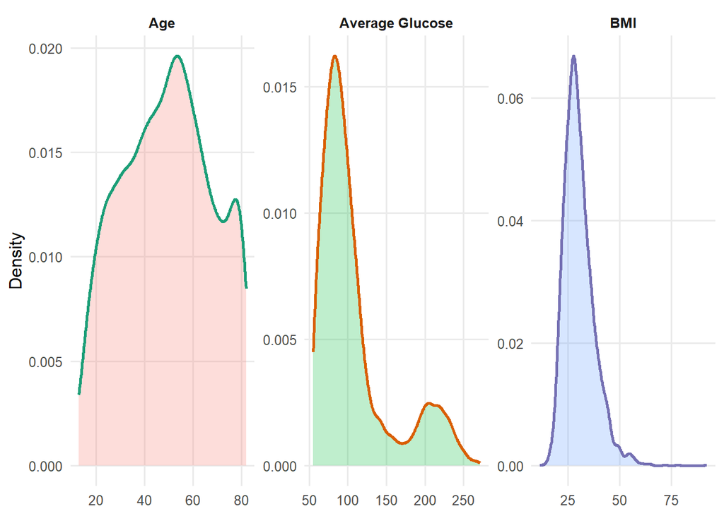

```r
library(tidyverse)

cont_long <- strokeclean %>%
  select(
    Age = age,
    BMI = bmi,
    `Average Glucose` = avg_glucose_level
  ) %>%
  pivot_longer(everything(), names_to = "Variable", values_to = "Value")

ggplot(cont_long, aes(Value, fill = Variable, colour = Variable)) +
  geom_density(alpha = 0.25, linewidth = 1) +
  facet_wrap(~ Variable, scales = "free", nrow = 1) +
  labs(x = NULL, y = "Density") +
  #palette = "Dark2") +
  scale_colour_brewer(palette = "Dark2") +
  theme_minimal(base_size = 12) +
  theme(
    strip.text = element_text(face = "bold"),
    legend.position = "none",
    panel.grid.minor = element_blank()
  )
```

**Interpretation of Key Continuous Predictors**

We examined the distributions of our three main numeric variables to identify patterns and potential risk factors.

- **Age** The age distribution is smooth, starting from late adolescence. The majority of individuals fall between **40 and 70 years old**, which corresponds to the population at highest risk for stroke. Since there are no extreme clusters or gaps, Age serves as an excellent continuous predictor.
- **Average Glucose Level** This variable shows a clear **right-skew**, meaning most people have normal levels, but there is a long “tail” of data extending above **200 mg/dL**. This highlights a specific subgroup of patients with poor metabolic health (likely indicating diabetes), which is a critical driver for heart disease and stroke risk.
- **BMI** BMI values are tightly grouped between **22 and 35**, with relatively few outliers. Because there is less variation here compared to Age or Glucose, it may play a slightly weaker role in distinguishing between stroke and non-stroke cases. This observation aligns with our regression results, where BMI showed a smaller contribution than vascular predictors.

**Distribution of Key Categorical Variables**

Bar charts help visualize population composition. The dataset shows more females than males, a balanced rural–urban distribution, and substantial variation in work type and smoking behavior.

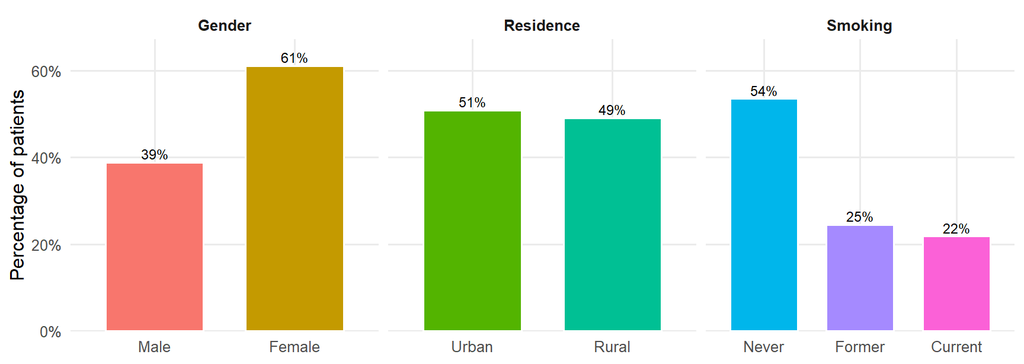

Figure 1: Sample composition by gender, residence type, and smoking status.

```r
library(dplyr)
library(tidyr)
library(ggplot2)
library(scales)

cat_df = strokeclean %>%
mutate(
gender = factor(gender, levels = c(1, 2),
labels = c("Male", "Female")),
Residence_type = factor(Residence_type, levels = c(1, 2),
labels = c("Urban", "Rural")),
smoking_status = factor(smoking_status,
levels = c(1, 2, 3),
labels = c("Never", "Former", "Current"))
) %>%
select(
Gender    = gender,
Residence = Residence_type,
Smoking   = smoking_status
) %>%
pivot_longer(
everything(),
names_to  = "Variable",
values_to = "Category"
) %>%
filter(!is.na(Category)) %>%
count(Variable, Category) %>%
group_by(Variable) %>%
mutate(prop = n / sum(n))

ggplot(cat_df, aes(x = Category, y = prop, fill = Category)) +
geom_col(width = 0.7, colour = "white") +
geom_text(aes(label = percent(prop, accuracy = 1)),
vjust = -0.3, size = 3) +
facet_wrap(~ Variable, scales = "free_x") +
scale_y_continuous(
labels = percent_format(accuracy = 1),
expand = expansion(mult = c(0, 0.10))
) +
labs(x = NULL, y = "Percentage of patients") +
theme_minimal(base_size = 12) +
theme(
legend.position  = "none",
strip.text       = element_text(face = "bold"),
panel.grid.minor = element_blank()
)
```

**Interpreatation**

- **Gender**:The dataset has more female patients (61%) than males (39%). This imbalance should be noted because gender-related model effects may partly reflect sample composition.
- **Residence Type**: The population is nearly evenly split between urban (51%) and rural (49%) residents. This indicates no geographic bias and good representation of both environments.
- **Smoking Status**: Most participants never smoked (54%), while 25% are former smokers and 22% are current smokers. This provides enough variation to meaningfully examine smoking as a behavioral risk factor for stroke.

**Stroke Risk for Clinical and Behavioral Predictors**

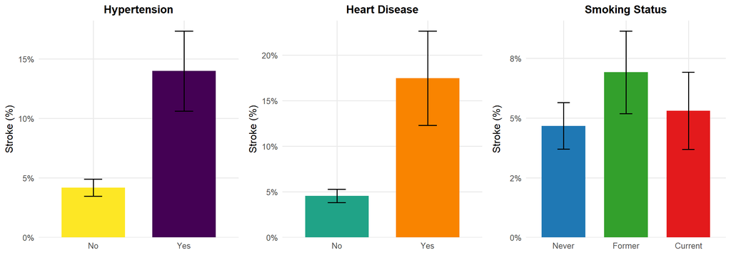

Figure 2: Stroke percentages (95% CI) by hypertension, heart disease, and smoking status.

```r
library(dplyr)
library(ggplot2)
library(ggpubr)
library(scales)

stopifnot(exists("strokeclean"))


strokeclean_plot = strokeclean %>%
  mutate(
    stroke = factor(stroke, levels = c("No", "Yes")),

    hypertension = factor(
      as.numeric(as.character(hypertension)),
      levels = c(0, 1),
      labels = c("No", "Yes")
    ),

    heart_disease = factor(
      as.numeric(as.character(heart_disease)),
      levels = c(0, 1),
      labels = c("No", "Yes")
    ),

    smoking_status = factor(
      as.numeric(as.character(smoking_status)),
      levels = c(1, 2, 3),
      labels = c("Never", "Former", "Current")
    )
  )

# 2. Helper: stroke proportion + 95% CI
prop_ci = function(data, group) {
  data %>%
    group_by({{ group }}) %>%
    summarise(
      stroke_rate = mean(stroke == "Yes"),
      n = n(),
      se = sqrt(stroke_rate * (1 - stroke_rate) / n),
      lower = pmax(0, stroke_rate - 1.96 * se),
      upper = pmin(1, stroke_rate + 1.96 * se),
      .groups = "drop"
    )
}


df_hyp   = prop_ci(strokeclean_plot, hypertension)
df_hd    = prop_ci(strokeclean_plot, heart_disease)
df_smoke = prop_ci(strokeclean_plot, smoking_status)


theme_stroke =
  theme_minimal(base_size = 12) +
  theme(
    panel.grid.minor = element_blank(),
    plot.title = element_text(face = "bold", size = 13, hjust = 0.5),
    axis.title.x = element_blank()
  )


cols_hyp   = c("No" = "#FDE725FF", "Yes" = "#440154FF")
cols_hd    = c("No" = "#20A387FF", "Yes" = "#F98400FF")
cols_smoke = c("Never" = "#1F78B4", "Former" = "#33A02C", "Current" = "#E31A1C")


p1 =
  ggplot(df_hyp, aes(x = hypertension, y = stroke_rate, fill = hypertension)) +
  geom_col(width = 0.7) +
  geom_errorbar(aes(ymin = lower, ymax = upper), width = 0.2) +
  scale_fill_manual(values = cols_hyp) +
  scale_y_continuous(
    labels = percent_format(accuracy = 1),
    expand = expansion(mult = c(0, 0.05))
  ) +
  labs(title = "Hypertension", y = "Stroke (%)") +
  theme_stroke +
  theme(legend.position = "none")

p2 =
  ggplot(df_hd, aes(x = heart_disease, y = stroke_rate, fill = heart_disease)) +
  geom_col(width = 0.7) +
  geom_errorbar(aes(ymin = lower, ymax = upper), width = 0.2) +
  scale_fill_manual(values = cols_hd) +
  scale_y_continuous(
    labels = percent_format(accuracy = 1),
    expand = expansion(mult = c(0, 0.05))
  ) +
  labs(title = "Heart Disease", y = "Stroke (%)") +
  theme_stroke +
  theme(legend.position = "none")

p3 =
  ggplot(df_smoke, aes(x = smoking_status, y = stroke_rate, fill = smoking_status)) +
  geom_col(width = 0.7) +
  geom_errorbar(aes(ymin = lower, ymax = upper), width = 0.2) +
  scale_fill_manual(values = cols_smoke) +
  scale_y_continuous(
    labels = percent_format(accuracy = 1),
    expand = expansion(mult = c(0, 0.05))
  ) +
  labs(title = "Smoking Status", y = "Stroke (%)") +
  theme_stroke +
  theme(legend.position = "none")


ggarrange(p1, p2, p3, ncol = 3, align = "hv")
```

**Interpretation**

The figure summarises how stroke *risk* varies across key categorical predictors:

- **Hypertension**
  - Stroke risk is clearly higher among hypertensive patients.
  - Confidence intervals show a noticeable separation, supporting a strong association.
- **Heart Disease**
  - Patients with heart disease show higher stroke percentages than those without.
  - The pattern is consistent with cardiovascular disease being a major clinical risk factor.
- **Smoking Status**
  - Former and current smokers have higher stroke percentages than never-smokers.
  - This reflects the long-term vascular effects of tobacco exposure.

Overall, these categorical predictors show patterns aligned with clinical expectations:  
vascular risks (hypertension, heart disease) and behavioural risks (smoking) are all associated with elevated stroke likelihood.

**Correlation among key numeric prediators**

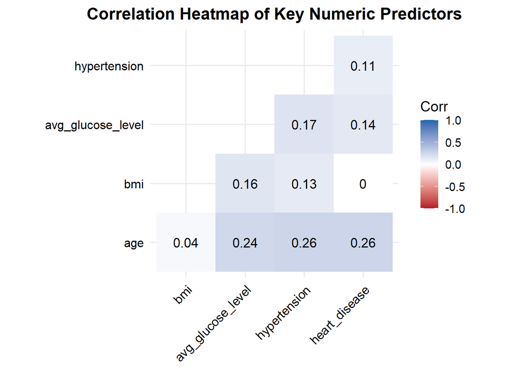

```r
library(ggcorrplot)
library(RColorBrewer)

# Select numeric predictors
numeric_vars = strokeclean[, c(
  "age", "bmi", "avg_glucose_level", "hypertension", "heart_disease"
)]

# Correlation matrix
corr_matrix = cor(numeric_vars)

# High-contrast heatmap
ggcorrplot(
  corr_matrix,
  method = "square",
  type = "lower",
  lab = TRUE,
  lab_size = 4.5,
  tl.cex = 12,
  tl.srt = 45,
  outline.col = NA,
  colors = c("#B2182B", "white", "#2166AC"),
  ggtheme = theme_minimal(base_size = 14)
) +
  ggtitle("Correlation Heatmap of Key Numeric Predictors") +
  theme(
    plot.title = element_text(face = "bold", size = 16, hjust = 0.5),
    axis.text  = element_text(color = "black", size = 11)
  )
```

**Interpretation**

- Correlation Heatmap of Key Numeric Predictors, all correlations are weak to moderate (0.00–0.26) = no multicollinearity concerns.
- Age shows small but meaningful positive correlations with:
- glucose (0.24)
- hypertension (0.26)
- heart disease (0.26) = consistent with known aging-related cardiovascular risk patterns.
- BMI has very weak correlations with all other predictors (0.04–0.16) = behaves independently in this dataset.
- Avg glucose moderately correlates with:
- hypertension (0.17)
- heart disease (0.14) = aligns with metabolic/vascular relationships.
- Hypertension and heart disease are weakly correlated (0.11) = related but not redundant.

These correlations confirm that the predictors provide unique, non-overlapping information, and all can be safely included in the logistic regression model without multicollinearity issues.

**Logistic Regression Model & its Coefficients**

```r
library(caret)

#| label: logit_fit
#| echo: true
#| warning: false
#| message: false

set.seed(123)

n <- nrow(strokeclean)
train_index <- sample(seq_len(n), size = 0.7 * n)

stroke_train <- strokeclean[train_index, ]
stroke_test  <- strokeclean[-train_index, ]

fit_glm <- glm(
  stroke ~ age + hypertension + heart_disease +
    avg_glucose_level + bmi + smoking_status +
    gender + ever_married,
  data   = stroke_train,
  family = binomial(link = "logit")
)

summary(fit_glm)
```

```
Call:
glm(formula = stroke ~ age + hypertension + heart_disease + avg_glucose_level +
    bmi + smoking_status + gender + ever_married, family = binomial(link = "logit"),
    data = stroke_train)

Coefficients:
                   Estimate Std. Error z value Pr(>|z|)
(Intercept)       -8.924079   0.992603  -8.991   <2e-16 ***
age                0.072637   0.008089   8.979   <2e-16 ***
hypertension       0.455377   0.229005   1.988   0.0468 *
heart_disease      0.487385   0.270707   1.800   0.0718 .
avg_glucose_level  0.003777   0.001705   2.215   0.0267 *
bmi                0.006536   0.015709   0.416   0.6774
smoking_status     0.234263   0.129934   1.803   0.0714 .
gender             0.230592   0.206934   1.114   0.2651
ever_married       0.118496   0.311030   0.381   0.7032
---
Signif. codes:  0 '***' 0.001 '**' 0.01 '*' 0.05 '.' 0.1 ' ' 1

(Dispersion parameter for binomial family taken to be 1)

    Null deviance: 953.42  on 2348  degrees of freedom
Residual deviance: 776.77  on 2340  degrees of freedom
AIC: 794.77

Number of Fisher Scoring iterations: 7
```

**Interpretation — Logistic Regression Coefficients**

- Age is a strong and highly significant predictor (p < 0.001). Higher age is associated with a substantial increase in the odds of stroke.
- Hypertension has a significant positive effect on stroke risk (p = 0.0468), indicating hypertensive individuals are more likely to experience stroke.
- Average glucose level is also a important predictor (p = 0.0267). Higher glucose values modestly increase stroke risk.
- Heart disease shows a positive association but is only borderline significant (p = 0.0718). This suggests a potential effect, but not statistically explainable in this model.
- Smoking has likewise borderline significant (p = 0.0714), indicating a increased risk among smokers, but the evidence is not too much strong.
- BMI, gender, and marital status show no meaningful statistical association with stroke in this dataset (all p > 0.26). These variables did not contribute substantially to prediction after accounting for other factors.
- Model fit improved substantially from the null model (deviance reduced from 953.4 to 776.8; AIC = 794.8), indicating a reasonable fit and useful predictive value.

**Odds ratios and confidence intervals**

```r
coef_est <- coef(fit_glm)
OR       <- exp(coef_est)

conf_int <- exp(confint(fit_glm))
odds_table <- cbind(OR, conf_int)
colnames(odds_table) <- c("OR", "2.5 %", "97.5 %")
round(odds_table, 3)
```

```
                     OR 2.5 % 97.5 %
(Intercept)       0.000 0.000  0.001
age               1.075 1.059  1.093
hypertension      1.577 0.996  2.450
heart_disease     1.628 0.942  2.732
avg_glucose_level 1.004 1.000  1.007
bmi               1.007 0.975  1.037
smoking_status    1.264 0.978  1.629
gender            1.259 0.843  1.901
ever_married      1.126 0.590  2.013
```

**Interpretation**

The logistic regression results give us a clear picture of how each predictor influences the likelihood of having a stroke, assuming all other factors stay the same.

**Model predictions and performance on the test set**

```r
library(caret)


stroke_test$pred_prob <- predict(
  fit_glm,
  newdata = stroke_test,
  type    = "response"
)


stroke_test$stroke <- factor(stroke_test$stroke,
                             levels = c("No", "Yes"))


stroke_test$pred_class <- ifelse(stroke_test$pred_prob >= 0.5, "Yes", "No")
stroke_test$pred_class <- factor(stroke_test$pred_class,
                                 levels = c("No", "Yes"))


cm <- confusionMatrix(
  data      = stroke_test$pred_class,
  reference = stroke_test$stroke,
  positive  = "Yes"
)

cm
```

```
Confusion Matrix and Statistics

          Reference
Prediction  No Yes
       No  949  58
       Yes   0   1

               Accuracy : 0.9425
                 95% CI : (0.9262, 0.956)
    No Information Rate : 0.9415
    P-Value [Acc > NIR] : 0.4811

                  Kappa : 0.0314

 Mcnemar's Test P-Value : 7.184e-14

            Sensitivity : 0.0169492
            Specificity : 1.0000000
         Pos Pred Value : 1.0000000
         Neg Pred Value : 0.9424032
             Prevalence : 0.0585317
         Detection Rate : 0.0009921
   Detection Prevalence : 0.0009921
      Balanced Accuracy : 0.5084746

       'Positive' Class : Yes
```

From the confusion matrix, the following performance metrics are defined:

**Accuracy**
$$\text{Accuracy} =
\frac{TP + TN}{TP + TN + FP + FN}.$$
**Sensitivity (Recall / True Positive Rate)**

$$\text{Sensitivity} =
\frac{TP}{TP + FN}.$$
**Specificity (True Negative Rate)**

$$\text{Specificity} =
\frac{TN}{TN + FP}.$$

**Positive Predictive Value (Precision)**
$$\text{PPV} =
\frac{TP}{TP + FP}.$$
**Negative Predictive Value (NPV)**

$$\text{NPV} =
\frac{TN}{TN + FN}.$$

**Interpretation of Logistic Regression Performance (Test Set)**

- Accuracy = 94.25% The model correctly classified most cases, mainly because the dataset is highly imbalanced (only ~6% stroke cases). High accuracy here does not mean good stroke detection.
- Sensitivity (True Positive Rate) = 0.017 The model correctly identified only 1 out of 59 actual stroke cases (≈1.7%). = This shows the model fails to detect stroke cases, which is common in rare-event medical datasets.
- Specificity (True Negative Rate) = 1.00 The model correctly classified all non-stroke cases. = It is extremely good at predicting “No stroke,” which dominates the dataset.
- Positive Predictive Value (Precision) = 1.00 When the model predicts “Yes,” it is always correct — but it predicted “Yes” only once. High precision is misleading because the model rarely predicts a positive case.
- Negative Predictive Value = 0.942 Most “No” predictions are correct, matching the overall class imbalance.
- Kappa = 0.031 Kappa measures agreement beyond chance. A value near zero shows the model performs only slightly better than random when considering class imbalance.
- Balanced Accuracy = 0.508 When weighting sensitivity and specificity equally, the model performs at chance level (~50%). = Confirms that stroke detection is weak.
- McNemar’s Test p < 0.0001 Strong evidence that the model’s errors are systematically skewed—it overwhelmingly predicts “No stroke.”

The logistic regression model achieves high accuracy only because the negative class dominates.It detects almost no true stroke cases, giving extremely poor sensitivity. It performs well for the majority class (non-stroke), but fails for the minority class (stroke).

These results highlight the challenge of severe class imbalance, which requires additional techniques (e.g., SMOTE, class weights, resampling) to improve medical-event prediction.

**ROC curve and AUC for the logistic model**

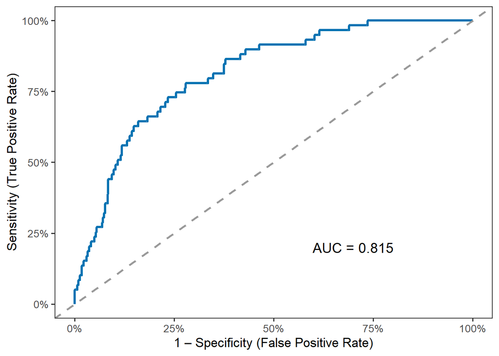

```r
library(pROC)
library(ggplot2)
library(scales)

# Compute ROC
roc_glm <- roc(
  response  = stroke_test$stroke,
  predictor = stroke_test$pred_prob,
  levels    = c("No","Yes"),
  direction = "<"
)

auc_val <- auc(roc_glm)

# Extract data for ggplot
roc_df <- data.frame(
  fpr = rev(1 - roc_glm$specificities),
  tpr = rev(roc_glm$sensitivities)
)

# Plot
ggplot(roc_df, aes(x = fpr, y = tpr)) +
  geom_line(color = "#0072B2", size = 1.2) +
  geom_abline(linetype = "dashed", color = "gray60", linewidth = 0.9) +
  scale_x_continuous(labels = percent_format(accuracy = 1)) +
  scale_y_continuous(labels = percent_format(accuracy = 1)) +
  labs(
    x = "1 – Specificity (False Positive Rate)",
    y = "Sensitivity (True Positive Rate)"
  ) +
  annotate("text",
           x = 0.70, y = 0.20,
           label = paste0("AUC = ", round(auc_val, 3)),
           size = 5) +
  theme_bw(base_size = 13) +
  theme(
    panel.grid.major = element_blank(),
    panel.grid.minor = element_blank()
  )
```

A higher AUC (closer to 1) indicates better discrimination between stroke and non-stroke cases. Values substantially above 0.5 indicate that the model performs better than random classification.

**Interpretation of ROC Curve and AUC (Test Set)**

The ROC curve evaluates the model’s ability to distinguish between stroke and non-stroke cases across all possible classification thresholds, not just the default 0.5 cutoff.

The AUC = 0.815, which indicates good discriminative performance.

AUC = 0.5 is no discrimination (random guessing)

AUC = 0.7–0.8 is acceptable

AUC = 0.8–0.9 is good

AUC > 0.9 is excellent

- Even though the confusion matrix showed poor sensitivity at threshold 0.5, the AUC reveals that the model can separate the two classes reasonably well if a better threshold is chosen.
- The strong AUC compared to weak sensitivity highlights the impact of severe class imbalance and the importance of customizing the probability cutoff for medical prediction tasks.

Overall, the ROC analysis suggests that the logistic model contains useful predictive signal, but performance for detecting stroke can be improved with:

- threshold tuning,
- cost-sensitive training,
- resampling techniques (SMOTE / oversampling).

**Machine-learning model comparison**

**Data Splitting and prepration**

```r
model_df <- strokeclean
model_df <- na.omit(model_df)
model_df$stroke <- factor(model_df$stroke)
levels(model_df$stroke) <- c("No", "Yes")
table(model_df$stroke)
```

```
  No  Yes
3177  180
```

```r
set.seed(123)
index <- createDataPartition(model_df$stroke, p = 0.70, list = FALSE)
train_data <- model_df[index, ]
test_data  <- model_df[-index, ]

train_data$stroke <- factor(train_data$stroke, levels = c("No","Yes"))
test_data$stroke  <- factor(test_data$stroke,  levels = c("No","Yes"))
```

**Train control settings**

```r
library(caret)

ctrl_none <- trainControl(
  method = "repeatedcv",
  number = 5,
  repeats = 3,
  classProbs = TRUE,
  summaryFunction = twoClassSummary,
  verboseIter = FALSE
)


# New control for SMOTE
ctrl_smote <- trainControl(
  method = "repeatedcv",
  number = 5,
  repeats = 3,
  classProbs = TRUE,
  summaryFunction = twoClassSummary,
  verboseIter = FALSE,
  # Add the SMOTE recipe step
  sampling = "smote"
)

# New control for ROSE
ctrl_rose <- trainControl(
  method = "repeatedcv",
  number = 5,
  repeats = 3,
  classProbs = TRUE,
  summaryFunction = twoClassSummary,
  verboseIter = FALSE,
  # Add the ROSE recipe step
  sampling = "rose"
)
```

**Logistic Regression (caret)**

```r
model_lr <- train(
stroke ~ .,
data = train_data,
method = "glm",
family = "binomial",
metric = "ROC",
trControl = ctrl_none
)
```

**Decision Tree**

```r
model_tree <- train(
stroke ~ .,
data = train_data,
method = "rpart",
metric = "ROC",
trControl = ctrl_none,
tuneLength = 10
)
```

**Random Forest**

```r
model_rf <- train(
stroke ~ .,
data = train_data,
method = "rf",
metric = "ROC",
trControl = ctrl_none,
tuneLength = 5
)
```

**Gradient Boosted Machine (GBM)**

```r
model_gbm <- train(
stroke ~ .,
data = train_data,
method = "gbm",
metric = "ROC",
trControl = ctrl_none,
verbose = FALSE
)
```

**k-Nearest Neighbours (k-NN)**

```r
model_knn <- train(
stroke ~ .,
data = train_data,
method = "knn",
metric = "ROC",
trControl = ctrl_none
)
```

**Support Vector Machine (Radial)**

```r
model_svm <- train(
stroke ~ .,
data = train_data,
method = "svmRadial",
metric = "ROC",
trControl = ctrl_none
)
```

**SMOTE Models Chunk (New)**

```r
# Logistic Regression with SMOTE
model_lr_smote <- train(
  stroke ~ .,
  data = train_data,
  method = "glm",
  family = "binomial",
  metric = "ROC",
  trControl = ctrl_smote
)

# Random Forest with SMOTE
model_rf_smote <- train(
  stroke ~ .,
  data = train_data,
  method = "rf",
  metric = "ROC",
  trControl = ctrl_smote
)

# GBM with SMOTE
model_gbm_smote <- train(
  stroke ~ .,
  data = train_data,
  method = "gbm",
  metric = "ROC",
  trControl = ctrl_smote,
  verbose = FALSE
)
```

**ROSE Models Chunk (New)**

```r
# Logistic Regression with ROSE
model_lr_rose <- train(
  stroke ~ .,
  data = train_data,
  method = "glm",
  family = "binomial",
  metric = "ROC",
  trControl = ctrl_rose
)

# Random Forest with ROSE
model_rf_rose <- train(
  stroke ~ .,
  data = train_data,
  method = "rf",
  metric = "ROC",
  trControl = ctrl_rose
)

# GBM with ROSE
model_gbm_rose <- train(
  stroke ~ .,
  data = train_data,
  method = "gbm",
  metric = "ROC",
  trControl = ctrl_rose,
  verbose = FALSE
)
```

**Model evaluation on the test set**

```r
library(pROC)
library(caret)
models_list <- list(
# 1. ORIGINAL MODELS (Trained with ctrl_none / No Resampling)
  #    These serve as your baseline to compare Sensitivity against.
  LR_None = model_lr,
  RF_None = model_rf,
  GBM_None = model_gbm,

  # 2. SMOTE RESAMPLED MODELS (Trained with ctrl_smote)
  #    We expect these to have significantly higher Sensitivity.
  LR_SMOTE = model_lr_smote,
  RF_SMOTE = model_rf_smote,
  GBM_SMOTE = model_gbm_smote,

  # 3. ROSE RESAMPLED MODELS (Trained with ctrl_rose)
  #    These provide an alternative balancing approach for comparison.
  LR_ROSE = model_lr_rose,
  RF_ROSE = model_rf_rose,
  GBM_ROSE = model_gbm_rose
)

results <- data.frame(
Model       = character(),
AUC         = numeric(),
Accuracy    = numeric(),
Sensitivity = numeric(),
Specificity = numeric()
)

for (m in names(models_list)) {
mdl <- models_list[[m]]



preds_prob  <- predict(mdl, test_data, type = "prob")[, "Yes"]



preds_class <- predict(mdl, test_data)



roc_obj <- roc(test_data$stroke, preds_prob,
levels = c("No", "Yes"), direction = "<")
auc_val <- auc(roc_obj)



cm_m <- confusionMatrix(preds_class, test_data$stroke, positive = "Yes")

results <- rbind(
results,
data.frame(
Model       = m,
AUC         = as.numeric(auc_val),
Accuracy    = cm_m$overall["Accuracy"],
Sensitivity = cm_m$byClass["Sensitivity"],
Specificity = cm_m$byClass["Specificity"]
)
)
}

results
```

```
              Model       AUC  Accuracy Sensitivity Specificity
Accuracy    LR_None 0.7793712 0.9433962  0.00000000   0.9968520
Accuracy1   RF_None 0.7250496 0.9463754  0.00000000   1.0000000
Accuracy2  GBM_None 0.7592884 0.9433962  0.00000000   0.9968520
Accuracy3  LR_SMOTE 0.7779332 0.7298908  0.62962963   0.7355719
Accuracy4  RF_SMOTE 0.7314620 0.9324727  0.01851852   0.9842602
Accuracy5 GBM_SMOTE 0.7551883 0.8848064  0.18518519   0.9244491
Accuracy6   LR_ROSE 0.7858225 0.7239325  0.66666667   0.7271773
Accuracy7   RF_ROSE 0.7392056 0.8609732  0.31481481   0.8919203
Accuracy8  GBM_ROSE 0.7791866 0.8361470  0.44444444   0.8583421
```

**ROC curve comparison across models**

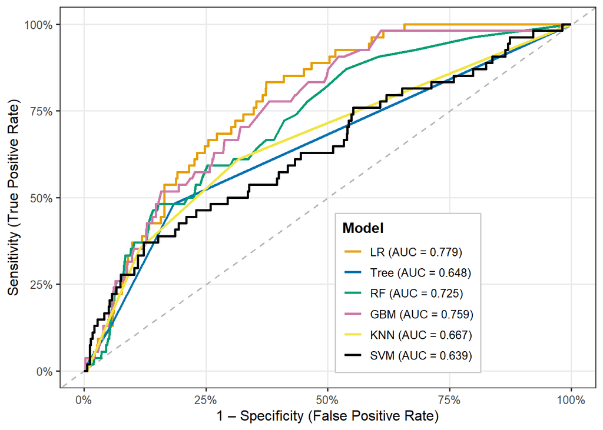

```r
library(scales)


roc_list <- list(
  LR   = roc(test_data$stroke,
             predict(model_lr,   test_data, type = "prob")[, "Yes"],
             levels = c("No","Yes"), direction = "<"),
  Tree = roc(test_data$stroke,
             predict(model_tree, test_data, type = "prob")[, "Yes"],
             levels = c("No","Yes"), direction = "<"),
  RF   = roc(test_data$stroke,
             predict(model_rf,   test_data, type = "prob")[, "Yes"],
             levels = c("No","Yes"), direction = "<"),
  GBM  = roc(test_data$stroke,
             predict(model_gbm,  test_data, type = "prob")[, "Yes"],
             levels = c("No","Yes"), direction = "<"),
  KNN  = roc(test_data$stroke,
             predict(model_knn,  test_data, type = "prob")[, "Yes"],
             levels = c("No","Yes"), direction = "<"),
  SVM  = roc(test_data$stroke,
             predict(model_svm,  test_data, type = "prob")[, "Yes"],
             levels = c("No","Yes"), direction = "<")
)


auc_vals <- sapply(roc_list, auc)


roc_df <- do.call(rbind, lapply(names(roc_list), function(m) {
  r <- roc_list[[m]]
  data.frame(
    model       = m,
    specificity = rev(r$specificities),
    sensitivity = rev(r$sensitivities)
  )
}))


roc_df$model <- factor(roc_df$model, levels = names(roc_list))


label_map <- paste0(names(auc_vals), " (AUC = ", sprintf("%.3f", auc_vals), ")")
names(label_map) <- names(auc_vals)


model_cols <- c(
  LR   = "#E69F00",
  Tree = "#0072B2",
  RF   = "#009E73",
  GBM  = "#CC79A7",
  KNN  = "#F0E442",
  SVM  = "#000000"
)


ggplot(roc_df, aes(x = 1 - specificity, y = sensitivity,
                   colour = model, group = model)) +
  geom_abline(intercept = 0, slope = 1,
              linetype = "dashed", colour = "grey70", linewidth = 0.6) +
  geom_line(linewidth = 1) +
  scale_color_manual(
    values = model_cols,
    breaks = names(label_map),
    labels = label_map,
    name   = "Model"
  ) +
  scale_x_continuous(labels = percent_format(accuracy = 1)) +
  scale_y_continuous(labels = percent_format(accuracy = 1)) +
  labs(
    x = "1 – Specificity (False Positive Rate)",
    y = "Sensitivity (True Positive Rate)"
  ) +
  theme_bw(base_size = 12) +
  theme(
    legend.position   = c(0.65, 0.25),
    legend.background = element_rect(fill = "white", colour = "grey80"),
    legend.title      = element_text(face = "bold"),
    panel.grid.minor  = element_blank()
  )
```

**Interpretation**

Interpretation of ROC Comparison Across Models

Logistic Regression (AUC = 0.779) performs the best among all six models, showing the strongest ability to differentiate stroke vs. non-stroke cases.

Random Forest (AUC = 0.725) and GBM (AUC = 0.759) also show good discriminative ability and are close competitors to logistic regression.

KNN (AUC = 0.667) performs moderately, better than random guessing but weaker than the tree-based and regression models.

Decision Tree (AUC = 0.648) and SVM (AUC = 0.639) show the lowest AUC values, indicating weaker predictive performance.

All models perform above 0.5, meaning they all do better than random chance — but with large differences in quality.

The ROC curves demonstrate that tree-based ensemble models (RF, GBM) and logistic regression extract more meaningful patterns from the data compared to simpler (Tree) and distance-based (KNN, SVM) methods.

Overall, logistic regression remains the most stable and best-performing model for this dataset, despite class imbalance challenges.

**Odds ratios and risk stratification**

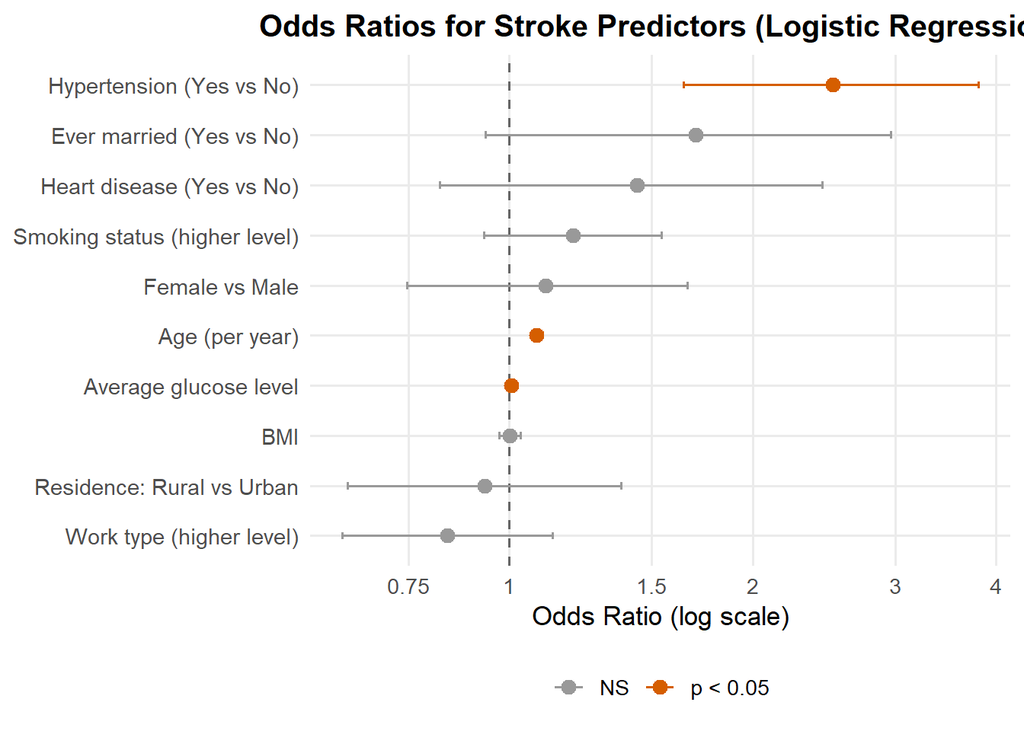

```r
library(ggplot2)
library(dplyr)
library(scales)



glm_lr <- glm(
stroke ~ age + gender + hypertension + heart_disease + ever_married +
work_type + Residence_type + avg_glucose_level + bmi + smoking_status,
data   = train_data,
family = binomial
)



lr_coef <- summary(glm_lr)$coefficients
ci_raw  <- suppressMessages(confint(glm_lr))

or_df <- data.frame(
Predictor = rownames(lr_coef),
logOR     = lr_coef[, "Estimate"],
OR        = exp(lr_coef[, "Estimate"]),
CI_lower  = exp(ci_raw[, 1]),
CI_upper  = exp(ci_raw[, 2]),
p_value   = lr_coef[, "Pr(>|z|)"]
) %>%



filter(Predictor != "(Intercept)") %>%



mutate(
Label = dplyr::recode(
Predictor,
age               = "Age (per year)",
gender            = "Female vs Male",
hypertension      = "Hypertension (Yes vs No)",
heart_disease     = "Heart disease (Yes vs No)",
ever_married      = "Ever married (Yes vs No)",
work_type         = "Work type (higher level)",
Residence_type    = "Residence: Rural vs Urban",
avg_glucose_level = "Average glucose level",
bmi               = "BMI",
smoking_status    = "Smoking status (higher level)"
),

Sig = ifelse(p_value < 0.05, "p < 0.05", "NS")
) %>%



arrange(OR) %>%
mutate(Label = factor(Label, levels = Label))



ggplot(or_df, aes(x = Label, y = OR, colour = Sig)) +
geom_hline(yintercept = 1, linetype = "dashed", colour = "grey40") +
geom_errorbar(aes(ymin = CI_lower, ymax = CI_upper),
width = 0.15, linewidth = 0.6) +
geom_point(size = 3) +
coord_flip() +
scale_y_log10(
breaks = c(0.5, 0.75, 1, 1.5, 2, 3, 4),
labels = c("0.5", "0.75", "1", "1.5", "2", "3", "4")
) +
scale_colour_manual(
values = c("p < 0.05" = "#D55E00", "NS" = "#999999")
) +
labs(
title  = "Odds Ratios for Stroke Predictors (Logistic Regression)",
x      = NULL,
y      = "Odds Ratio (log scale)",
colour = NULL
) +
theme_minimal(base_size = 13) +
theme(
panel.grid.minor = element_blank(),
plot.title       = element_text(face = "bold", hjust = 0.5, size = 15),
axis.text.y      = element_text(size = 11),
legend.position  = "bottom"
)
```

**Interpretation**

- Hypertension (Yes vs No)

This is the strongest predictor. Its OR is clearly > 2, and the whole 95% CI lies above 1 (orange point), meaning hypertensive patients have more than double the odds of stroke, with strong statistical evidence.

- Age (per year)

The OR is slightly above 1 with a narrow CI fully above 1 (orange).

Each additional year of age increases stroke odds by a small but consistent amount, making age an important continuous risk factor.

- Average glucose level

OR is just above 1 with a tight CI above 1 (orange).

Higher glucose is associated with a modest but statistically reliable increase in stroke risk, consistent with metabolic / diabetes-related vascular risk.

- Ever married, heart disease, smoking status, gender, BMI, residence, work type

Their confidence intervals all cross 1 (grey points), so in this multivariable model they do not show statistically significant effects after adjusting for age, hypertension and glucose.Some (e.g., heart disease, smoking) still have ORs above 1, suggesting possible elevated risk, but the evidence is weaker in this dataset.

Overall message: The forest plot shows that, after adjusting for other variables, hypertension, older age, and higher average glucose level are the clearest independent predictors of stroke, while other factors have smaller or more uncertain effects. This aligns well with established clinical knowledge and supports your logistic regression model as a sensible risk-stratification tool.

**Threshold tuning to 0.2 from 0.5**

```r
new_threshold <- 0.2

stroke_test$pred_class_02 <- ifelse(stroke_test$pred_prob >= new_threshold,
                                    "Yes", "No")

stroke_test$pred_class_02 <- factor(stroke_test$pred_class_02,
                                    levels = c("No", "Yes"))


cm_02 <- confusionMatrix(
  data      = stroke_test$pred_class_02,
  reference = stroke_test$stroke,
  positive  = "Yes"
)

cm_02
```

```
Confusion Matrix and Statistics

          Reference
Prediction  No Yes
       No  903  46
       Yes  46  13

               Accuracy : 0.9087
                 95% CI : (0.8892, 0.9258)
    No Information Rate : 0.9415
    P-Value [Acc > NIR] : 1

                  Kappa : 0.1719

 Mcnemar's Test P-Value : 1

            Sensitivity : 0.22034
            Specificity : 0.95153
         Pos Pred Value : 0.22034
         Neg Pred Value : 0.95153
             Prevalence : 0.05853
         Detection Rate : 0.01290
   Detection Prevalence : 0.05853
      Balanced Accuracy : 0.58593

       'Positive' Class : Yes
```

**Interpretation (threshold = 0.2**

- With a lower decision criterion of 0.2, the model successfully identifies 13 out of 59 stroke cases (sensitivity = 22%), compared to only one case with the default 0.5 threshold.
- Specificity remains high at almost 95%, indicating that the majority of non-stroke patients are still properly categorized as “no stroke” (903 out of 949).
- While overall accuracy declines from 94% to 91%, balanced accuracy improves (from ≈0.51 to ≈0.59), indicating a greater balance of sensitivity and specificity.

This change indicates a therapeutically reasonable compromise: the model detects more possible stroke patients (fewer missed cases) at the expense of a moderate rise in false positives.

# 4 Conclusion

#References